# Edge angle experiments

## Imports

```python
import numpy as np
import pymc3 as pm
import pandas as pd
import matplotlib.pyplot as plt
import seaborn as sns; sns.set()
from scipy.stats import norm
from sklearn.preprocessing import LabelEncoder
from theano import tensor as tt
from sys import exit
import pickle
import arviz
import re
```

```
WARNING (theano.tensor.blas): Using NumPy C-API based implementation for BLAS functions.
```

```python
writeOut = False
```

```python
path = './Plots_New/'
```

## Plot settings

```python
widthMM = 190
widthInch = widthMM / 25.4
ratio = 0.66
heigthInch = ratio*widthInch
aspect = widthInch / heigthInch
```

```python
SMALL_SIZE = 8
MEDIUM_SIZE = 10
BIGGER_SIZE = 12

plt.rc('font', size=SMALL_SIZE)          # controls default text sizes
plt.rc('axes', titlesize=SMALL_SIZE)     # fontsize of the axes title
plt.rc('axes', labelsize=MEDIUM_SIZE)    # fontsize of the x and y labels
plt.rc('xtick', labelsize=SMALL_SIZE)    # fontsize of the tick labels
plt.rc('ytick', labelsize=SMALL_SIZE)    # fontsize of the tick labels
plt.rc('legend', fontsize=SMALL_SIZE)    # legend fontsize
plt.rc('figure', titlesize=BIGGER_SIZE)  # fontsize of the figure title
sns.set_style("ticks")
```

## Load data

Read in all excel sheets at once into one big table.

```python
df = pd.concat([pd.read_excel("data/SEC-NUM-10_SEC-R-15_EAP-flake_1_E1.xlsx"), pd.read_excel("data/SEC-NUM-10_SEC-R-15_WEM-60_1_E1.xlsx"),pd.read_excel("data/SEC-NUM-10_SEC-R-15_BU-072_1_E1.xlsx")], axis=0)
df.reset_index().dropna("columns").drop('index', 1)
```

|  | section | angle_number | steps | dist_intersection | segment_length | 3points | 2lines | best_fit |
| --- | --- | --- | --- | --- | --- | --- | --- | --- |
| 0 | EAP-flake_1_E1_RE_SEC-01_local | 1 | 0.2 | 0.2 | 0.5 | 116.6 | 111.3 | 107.4 |
| 1 | EAP-flake_1_E1_RE_SEC-01_local | 2 | 0.2 | 0.4 | 0.5 | 106.0 | 95.6 | 98.9 |
| 2 | EAP-flake_1_E1_RE_SEC-01_local | 3 | 0.2 | 0.6 | 0.5 | 105.4 | 80.1 | 79.6 |
| 3 | EAP-flake_1_E1_RE_SEC-01_local | 4 | 0.2 | 0.8 | 0.5 | 93.0 | 53.4 | 55.9 |
| 4 | EAP-flake_1_E1_RE_SEC-01_local | 5 | 0.2 | 1.0 | 0.5 | 84.6 | 52.3 | 50.8 |
| ... | ... | ... | ... | ... | ... | ... | ... | ... |
| 4302 | BU-072_1_E1_RE_SEC-10_local | 10 | 1.0 | 10.0 | 1.0 | 61.6 | 27.0 | 27.7 |
| 4303 | BU-072_1_E1_RE_SEC-10_local | 11 | 1.0 | 11.0 | 1.0 | 57.1 | 9.6 | 9.9 |
| 4304 | BU-072_1_E1_RE_SEC-10_local | 12 | 1.0 | 12.0 | 1.0 | 53.1 | 13.7 | 13.5 |
| 4305 | BU-072_1_E1_RE_SEC-10_local | 13 | 1.0 | 13.0 | 1.0 | 49.4 | 8.6 | 9.8 |
| 4306 | BU-072_1_E1_RE_SEC-10_local | 14 | 1.0 | 14.0 | 1.0 | 46.3 | 24.7 | 150.4 |

4307 rows × 8 columns

Add extra columns for location and object.

```python
df['location'] = df.apply(lambda r: int(re.findall(r'\d+', r.section)[-1]),axis=1)
df['object'] = df.apply(lambda r: r.section.split('-')[0],axis=1)
```

```python
df
```

|  | section | angle_number | steps | dist_intersection | segment_length | 3points | 2lines | best_fit | location | object |
| --- | --- | --- | --- | --- | --- | --- | --- | --- | --- | --- |
| 0 | EAP-flake_1_E1_RE_SEC-01_local | 1 | 0.2 | 0.2 | 0.5 | 116.6 | 111.3 | 107.4 | 1 | EAP |
| 1 | EAP-flake_1_E1_RE_SEC-01_local | 2 | 0.2 | 0.4 | 0.5 | 106.0 | 95.6 | 98.9 | 1 | EAP |
| 2 | EAP-flake_1_E1_RE_SEC-01_local | 3 | 0.2 | 0.6 | 0.5 | 105.4 | 80.1 | 79.6 | 1 | EAP |
| 3 | EAP-flake_1_E1_RE_SEC-01_local | 4 | 0.2 | 0.8 | 0.5 | 93.0 | 53.4 | 55.9 | 1 | EAP |
| 4 | EAP-flake_1_E1_RE_SEC-01_local | 5 | 0.2 | 1.0 | 0.5 | 84.6 | 52.3 | 50.8 | 1 | EAP |
| ... | ... | ... | ... | ... | ... | ... | ... | ... | ... | ... |
| 1411 | BU-072_1_E1_RE_SEC-10_local | 10 | 1.0 | 10.0 | 1.0 | 61.6 | 27.0 | 27.7 | 10 | BU |
| 1412 | BU-072_1_E1_RE_SEC-10_local | 11 | 1.0 | 11.0 | 1.0 | 57.1 | 9.6 | 9.9 | 10 | BU |
| 1413 | BU-072_1_E1_RE_SEC-10_local | 12 | 1.0 | 12.0 | 1.0 | 53.1 | 13.7 | 13.5 | 10 | BU |
| 1414 | BU-072_1_E1_RE_SEC-10_local | 13 | 1.0 | 13.0 | 1.0 | 49.4 | 8.6 | 9.8 | 10 | BU |
| 1415 | BU-072_1_E1_RE_SEC-10_local | 14 | 1.0 | 14.0 | 1.0 | 46.3 | 24.7 | 150.4 | 10 | BU |

4307 rows × 10 columns

Convert three method column to columns 'edge_angle' and 'method'.

```python
otherCols = ['section','angle_number','steps','dist_intersection','segment_length','location','object']
df = pd.melt(df, value_vars=['3points', '2lines','best_fit'], id_vars=otherCols, var_name='method',value_name='edge_angle')
```

```python
df
```

|  | section | angle_number | steps | dist_intersection | segment_length | location | object | method | edge_angle |
| --- | --- | --- | --- | --- | --- | --- | --- | --- | --- |
| 0 | EAP-flake_1_E1_RE_SEC-01_local | 1 | 0.2 | 0.2 | 0.5 | 1 | EAP | 3points | 116.6 |
| 1 | EAP-flake_1_E1_RE_SEC-01_local | 2 | 0.2 | 0.4 | 0.5 | 1 | EAP | 3points | 106.0 |
| 2 | EAP-flake_1_E1_RE_SEC-01_local | 3 | 0.2 | 0.6 | 0.5 | 1 | EAP | 3points | 105.4 |
| 3 | EAP-flake_1_E1_RE_SEC-01_local | 4 | 0.2 | 0.8 | 0.5 | 1 | EAP | 3points | 93.0 |
| 4 | EAP-flake_1_E1_RE_SEC-01_local | 5 | 0.2 | 1.0 | 0.5 | 1 | EAP | 3points | 84.6 |
| ... | ... | ... | ... | ... | ... | ... | ... | ... | ... |
| 12916 | BU-072_1_E1_RE_SEC-10_local | 10 | 1.0 | 10.0 | 1.0 | 10 | BU | best_fit | 27.7 |
| 12917 | BU-072_1_E1_RE_SEC-10_local | 11 | 1.0 | 11.0 | 1.0 | 10 | BU | best_fit | 9.9 |
| 12918 | BU-072_1_E1_RE_SEC-10_local | 12 | 1.0 | 12.0 | 1.0 | 10 | BU | best_fit | 13.5 |
| 12919 | BU-072_1_E1_RE_SEC-10_local | 13 | 1.0 | 13.0 | 1.0 | 10 | BU | best_fit | 9.8 |
| 12920 | BU-072_1_E1_RE_SEC-10_local | 14 | 1.0 | 14.0 | 1.0 | 10 | BU | best_fit | 150.4 |

12921 rows × 9 columns

Use the filter criterion dist_intersection' only 2.0mm, 5.0mm und 10.0mm and 0.5mm 'segment_length' each.

```python
df = df[(df.segment_length == 0.5) & ((df.dist_intersection == 2.0)  | (df.dist_intersection == 5.0) | (df.dist_intersection == 10.0) ) ]
```

Furthermore I renamed 'location' to 'sectionNumber'.

```python
df = df.rename(columns={"location": "sectionNumber"})
```

```python
df
```

|  | section | angle_number | steps | dist_intersection | segment_length | sectionNumber | object | method | edge_angle |
| --- | --- | --- | --- | --- | --- | --- | --- | --- | --- |
| 9 | EAP-flake_1_E1_RE_SEC-01_local | 10 | 0.2 | 2.0 | 0.5 | 1 | EAP | 3points | 63.7 |
| 24 | EAP-flake_1_E1_RE_SEC-01_local | 25 | 0.2 | 5.0 | 0.5 | 1 | EAP | 3points | 37.7 |
| 49 | EAP-flake_1_E1_RE_SEC-01_local | 50 | 0.2 | 10.0 | 0.5 | 1 | EAP | 3points | 8.1 |
| 55 | EAP-flake_1_E1_RE_SEC-01_local | 4 | 0.5 | 2.0 | 0.5 | 1 | EAP | 3points | 63.7 |
| 61 | EAP-flake_1_E1_RE_SEC-01_local | 10 | 0.5 | 5.0 | 0.5 | 1 | EAP | 3points | 37.7 |
| ... | ... | ... | ... | ... | ... | ... | ... | ... | ... |
| 12858 | BU-072_1_E1_RE_SEC-10_local | 10 | 0.5 | 5.0 | 0.5 | 10 | BU | best_fit | 72.5 |
| 12868 | BU-072_1_E1_RE_SEC-10_local | 20 | 0.5 | 10.0 | 0.5 | 10 | BU | best_fit | 33.6 |
| 12894 | BU-072_1_E1_RE_SEC-10_local | 2 | 1.0 | 2.0 | 0.5 | 10 | BU | best_fit | 81.5 |
| 12897 | BU-072_1_E1_RE_SEC-10_local | 5 | 1.0 | 5.0 | 0.5 | 10 | BU | best_fit | 72.5 |
| 12902 | BU-072_1_E1_RE_SEC-10_local | 10 | 1.0 | 10.0 | 0.5 | 10 | BU | best_fit | 33.6 |

801 rows × 9 columns

### Check for triple values

Read in the raw data again.

```python
raw = pd.read_excel("data/SEC-NUM-10_SEC-R-15_BU-072_1_E1.xlsx")
raw
```

|  | section | angle_number | steps | dist_intersection | segment_length | 3points | 2lines | best_fit |
| --- | --- | --- | --- | --- | --- | --- | --- | --- |
| 0 | BU-072_1_E1_RE_SEC-01_local | 1 | 0.2 | 0.2 | 0.5 | 76.3 | 68.6 | 95.9 |
| 1 | BU-072_1_E1_RE_SEC-01_local | 2 | 0.2 | 0.4 | 0.5 | 63.6 | 46.2 | 46.1 |
| 2 | BU-072_1_E1_RE_SEC-01_local | 3 | 0.2 | 0.6 | 0.5 | 55.6 | 39.9 | 39.3 |
| 3 | BU-072_1_E1_RE_SEC-01_local | 4 | 0.2 | 0.8 | 0.5 | 50.9 | 35.5 | 37.1 |
| 4 | BU-072_1_E1_RE_SEC-01_local | 5 | 0.2 | 1.0 | 0.5 | 47.3 | 34.3 | 33.2 |
| ... | ... | ... | ... | ... | ... | ... | ... | ... |
| 1411 | BU-072_1_E1_RE_SEC-10_local | 10 | 1.0 | 10.0 | 1.0 | 61.6 | 27.0 | 27.7 |
| 1412 | BU-072_1_E1_RE_SEC-10_local | 11 | 1.0 | 11.0 | 1.0 | 57.1 | 9.6 | 9.9 |
| 1413 | BU-072_1_E1_RE_SEC-10_local | 12 | 1.0 | 12.0 | 1.0 | 53.1 | 13.7 | 13.5 |
| 1414 | BU-072_1_E1_RE_SEC-10_local | 13 | 1.0 | 13.0 | 1.0 | 49.4 | 8.6 | 9.8 |
| 1415 | BU-072_1_E1_RE_SEC-10_local | 14 | 1.0 | 14.0 | 1.0 | 46.3 | 24.7 | 150.4 |

1416 rows × 8 columns

```python
raw[(raw.best_fit == 121.4) | (raw.best_fit == 26.8) ]
```

|  | section | angle_number | steps | dist_intersection | segment_length | 3points | 2lines | best_fit |
| --- | --- | --- | --- | --- | --- | --- | --- | --- |
| 139 | BU-072_1_E1_RE_SEC-01_local | 5 | 1.0 | 5.0 | 1.0 | 34.2 | 25.9 | 26.8 |
| 503 | BU-072_1_E1_RE_SEC-04_local | 61 | 0.2 | 12.2 | 0.5 | 38.2 | 29.9 | 26.8 |

An explicit query for duplicate lines (i.e. all entries the same) yields nothing.

```python
 df[df.duplicated(keep=False)]
```

|  | section | angle_number | steps | dist_intersection | segment_length | sectionNumber | object | method | edge_angle |
| --- | --- | --- | --- | --- | --- | --- | --- | --- | --- |

## Check that the angle is equal to 60° for WEM

First, the section is averaged over, then the dist_intersection.

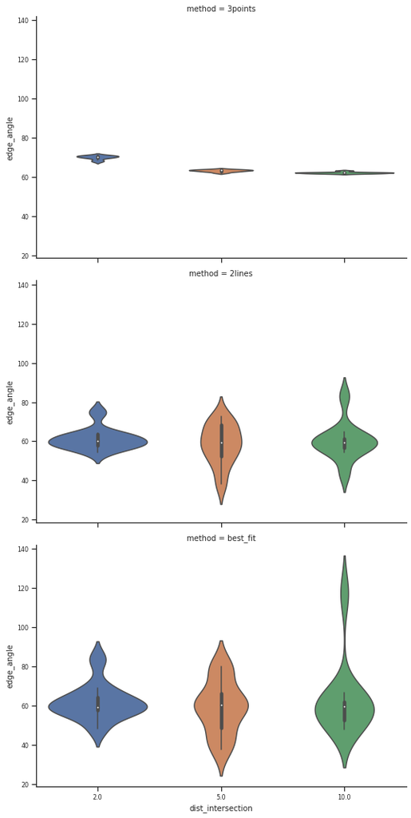

```python
sns.catplot(data=df[df.object == 'WEM'],x='dist_intersection',y='edge_angle',row='method',kind='violin',height=heigthInch,aspect=aspect)
plt.savefig(path + "Check_WEM_dist.pdf", bbox_inches='tight',dpi= 300)
```

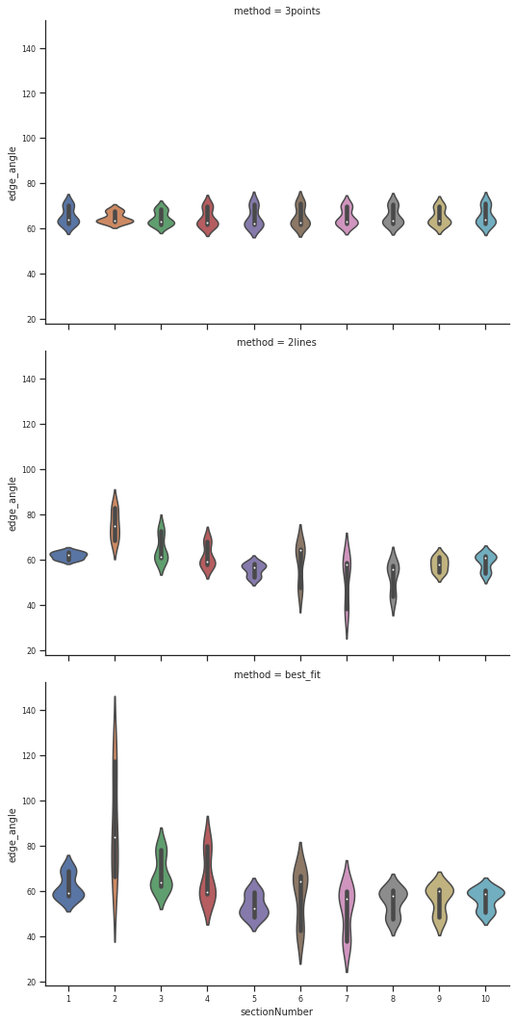

```python
sns.catplot(data=df[df.object == 'WEM'],x='sectionNumber',y='edge_angle',row='method',kind='violin',height=heigthInch,aspect=aspect)
plt.savefig(path + "Check_WEM_sec.pdf", bbox_inches='tight',dpi= 300)
```

## Show the variance of the angles along the edge, i. e. for the different locations

We look at the angle for all objects, all locations and all methods. The depth is averaged over.

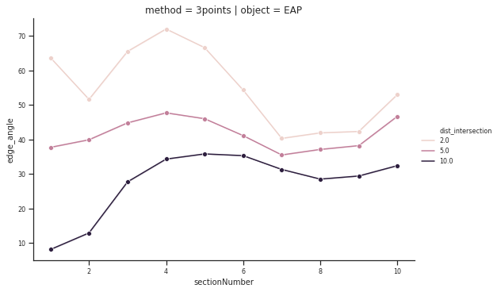

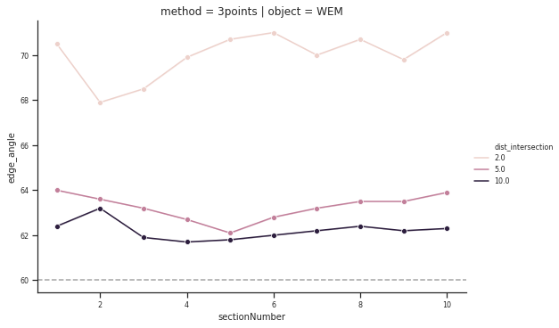

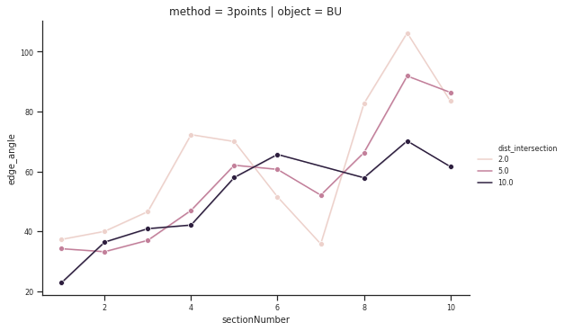

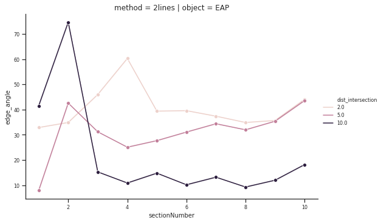

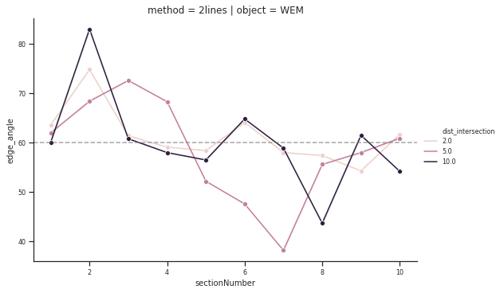

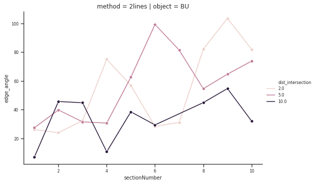

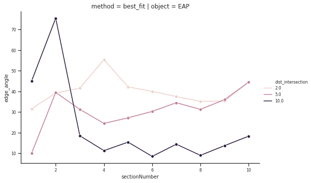

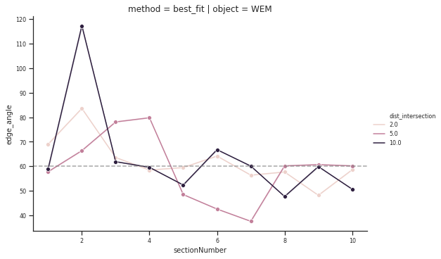

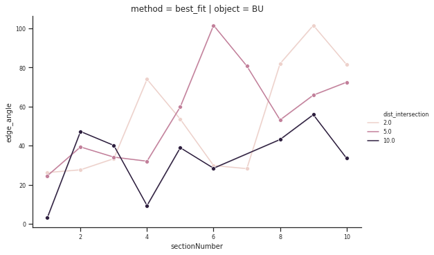

```python
for method in df.method.unique():
    for objectName in df.object.unique():
        data = df[(df.method == method) & (df.object == objectName)]
        ax = sns.relplot(data=data,x='sectionNumber',y='edge_angle',kind='line',hue='dist_intersection',legend="full",height=heigthInch,aspect=aspect, marker='o')
        plt.title("method = {} | object = {}".format(method,objectName), fontsize=BIGGER_SIZE)
        if objectName == "WEM":
            plt.axhline(y=60,color='gray',alpha=0.7,ls='--')
        plt.savefig(path + "Along_edge_{}_{}.pdf".format(method,objectName), bbox_inches='tight',dpi= 300)
```

## Show differences between methods on the two other samples

We look at the angle on the two other objects by all methods for all locations and depths.

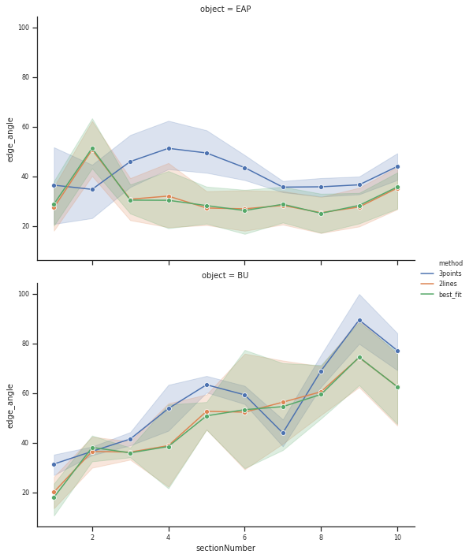

```python
sns.relplot(data=df[ ~(df.object == 'WEM') ],x='sectionNumber',y='edge_angle',hue='method',row='object',height=heigthInch,aspect=aspect,kind='line', marker='o')
plt.savefig(path + "EAP_BU.pdf", bbox_inches='tight',dpi= 300)
```

## Overall goal is to access which method is most suitable

## Method

In statistics, a quality measure that is often used is the [mean squared error](https://en.wikipedia.org/wiki/Mean_square_error).

We can evaluate the mean squared error for the WEM object under the assumption that the true angle for all sections is 60°.

```python
dfMS = df[df.object == 'WEM']
trueAngle = 60.0
dfMS = dfMS.assign(squaredError=dfMS.edge_angle.apply( lambda x: np.power(x - trueAngle,2)))
dfMS.groupby(['method','dist_intersection']).mean()['squaredError']
```

```
method    dist_intersection
2lines    2.0                   30.028
          5.0                  101.622
          10.0                  87.173
3points   2.0                  100.994
          5.0                   10.869
          10.0                   5.047
best_fit  2.0                   83.051
          5.0                  170.279
          10.0                 363.007
Name: squaredError, dtype: float64
```

## Result

We see that the minimum squared error is realized by the 3points method at dist_intersection = 10.0 and is thus the recommended method.

As a sanity check I look at the number of data points and manually inspect the results:

```python
dfMS.groupby(['method','dist_intersection']).count()['squaredError']
```

```
method    dist_intersection
2lines    2.0                  30
          5.0                  30
          10.0                 30
3points   2.0                  30
          5.0                  30
          10.0                 30
best_fit  2.0                  30
          5.0                  30
          10.0                 30
Name: squaredError, dtype: int64
```

```python
df[(df.object == 'WEM') & (df.method == '3points') & (df.dist_intersection == 10.0)]
```

|  | section | angle_number | steps | dist_intersection | segment_length | sectionNumber | object | method | edge_angle |
| --- | --- | --- | --- | --- | --- | --- | --- | --- | --- |
| 1447 | WEM-60_1_E1_RE_SEC-01_local | 50 | 0.2 | 10.0 | 0.5 | 1 | WEM | 3points | 62.4 |
| 1492 | WEM-60_1_E1_RE_SEC-01_local | 20 | 0.5 | 10.0 | 0.5 | 1 | WEM | 3points | 62.4 |
| 1527 | WEM-60_1_E1_RE_SEC-01_local | 10 | 1.0 | 10.0 | 0.5 | 1 | WEM | 3points | 62.4 |
| 1596 | WEM-60_1_E1_RE_SEC-02_local | 50 | 0.2 | 10.0 | 0.5 | 2 | WEM | 3points | 63.2 |
| 1641 | WEM-60_1_E1_RE_SEC-02_local | 20 | 0.5 | 10.0 | 0.5 | 2 | WEM | 3points | 63.2 |
| 1676 | WEM-60_1_E1_RE_SEC-02_local | 10 | 1.0 | 10.0 | 0.5 | 2 | WEM | 3points | 63.2 |
| 1745 | WEM-60_1_E1_RE_SEC-03_local | 50 | 0.2 | 10.0 | 0.5 | 3 | WEM | 3points | 61.9 |
| 1790 | WEM-60_1_E1_RE_SEC-03_local | 20 | 0.5 | 10.0 | 0.5 | 3 | WEM | 3points | 61.9 |
| 1825 | WEM-60_1_E1_RE_SEC-03_local | 10 | 1.0 | 10.0 | 0.5 | 3 | WEM | 3points | 61.9 |
| 1894 | WEM-60_1_E1_RE_SEC-04_local | 50 | 0.2 | 10.0 | 0.5 | 4 | WEM | 3points | 61.7 |
| 1939 | WEM-60_1_E1_RE_SEC-04_local | 20 | 0.5 | 10.0 | 0.5 | 4 | WEM | 3points | 61.7 |
| 1974 | WEM-60_1_E1_RE_SEC-04_local | 10 | 1.0 | 10.0 | 0.5 | 4 | WEM | 3points | 61.7 |
| 2043 | WEM-60_1_E1_RE_SEC-05_local | 50 | 0.2 | 10.0 | 0.5 | 5 | WEM | 3points | 61.8 |
| 2088 | WEM-60_1_E1_RE_SEC-05_local | 20 | 0.5 | 10.0 | 0.5 | 5 | WEM | 3points | 61.8 |
| 2123 | WEM-60_1_E1_RE_SEC-05_local | 10 | 1.0 | 10.0 | 0.5 | 5 | WEM | 3points | 61.8 |
| 2192 | WEM-60_1_E1_RE_SEC-06_local | 50 | 0.2 | 10.0 | 0.5 | 6 | WEM | 3points | 62.0 |
| 2237 | WEM-60_1_E1_RE_SEC-06_local | 20 | 0.5 | 10.0 | 0.5 | 6 | WEM | 3points | 62.0 |
| 2272 | WEM-60_1_E1_RE_SEC-06_local | 10 | 1.0 | 10.0 | 0.5 | 6 | WEM | 3points | 62.0 |
| 2341 | WEM-60_1_E1_RE_SEC-07_local | 50 | 0.2 | 10.0 | 0.5 | 7 | WEM | 3points | 62.2 |
| 2386 | WEM-60_1_E1_RE_SEC-07_local | 20 | 0.5 | 10.0 | 0.5 | 7 | WEM | 3points | 62.2 |
| 2421 | WEM-60_1_E1_RE_SEC-07_local | 10 | 1.0 | 10.0 | 0.5 | 7 | WEM | 3points | 62.2 |
| 2490 | WEM-60_1_E1_RE_SEC-08_local | 50 | 0.2 | 10.0 | 0.5 | 8 | WEM | 3points | 62.4 |
| 2535 | WEM-60_1_E1_RE_SEC-08_local | 20 | 0.5 | 10.0 | 0.5 | 8 | WEM | 3points | 62.4 |
| 2570 | WEM-60_1_E1_RE_SEC-08_local | 10 | 1.0 | 10.0 | 0.5 | 8 | WEM | 3points | 62.4 |
| 2639 | WEM-60_1_E1_RE_SEC-09_local | 50 | 0.2 | 10.0 | 0.5 | 9 | WEM | 3points | 62.2 |
| 2685 | WEM-60_1_E1_RE_SEC-09_local | 20 | 0.5 | 10.0 | 0.5 | 9 | WEM | 3points | 62.2 |
| 2720 | WEM-60_1_E1_RE_SEC-09_local | 10 | 1.0 | 10.0 | 0.5 | 9 | WEM | 3points | 62.2 |
| 2789 | WEM-60_1_E1_RE_SEC-10_local | 50 | 0.2 | 10.0 | 0.5 | 10 | WEM | 3points | 62.3 |
| 2835 | WEM-60_1_E1_RE_SEC-10_local | 20 | 0.5 | 10.0 | 0.5 | 10 | WEM | 3points | 62.3 |
| 2870 | WEM-60_1_E1_RE_SEC-10_local | 10 | 1.0 | 10.0 | 0.5 | 10 | WEM | 3points | 62.3 |

## Prediction

Having choosen the method, the results on the other two objects now look as follows:

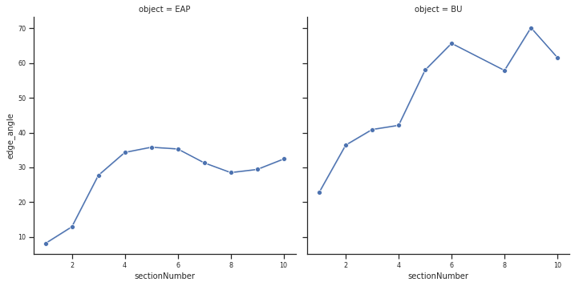

```python
sns.relplot(data=df[ ~(df.object == 'WEM') & (df.method == '3points') & (df.dist_intersection == 10.0)],x='sectionNumber',y='edge_angle',col='object',kind='line', marker='o')
```

## Write out

```python
!jupyter nbconvert --to html EdgeAnglesV4.ipynb
```

```python
!jupyter nbconvert --to markdown EdgeAnglesV4.ipynb
```